# Métodos Computacionais para Análise de Risco

25 de Junho de 2018

## Sobre a Base

- É uma base de dados contendo dados de frequência de sinistros e valor médio de indenizações e prêmios de carros de todo o país.
- Foram retirados do site da Susep.
- O banco contém 393.071 observações e 14 variáveis.
- Selecionamos apenas o modelo gol 1.0 ano 2009 da região metropolitana de BH para fazermos a análise.

## Análise Descritiva

## Análise Descritiva

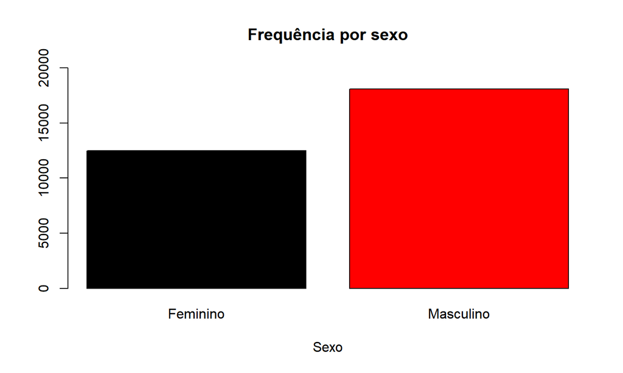

## Análise Descritiva

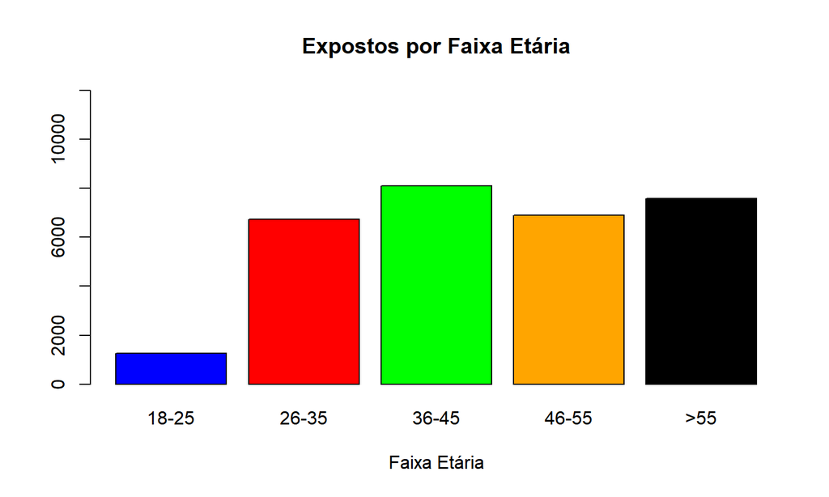

## Análise Descritiva

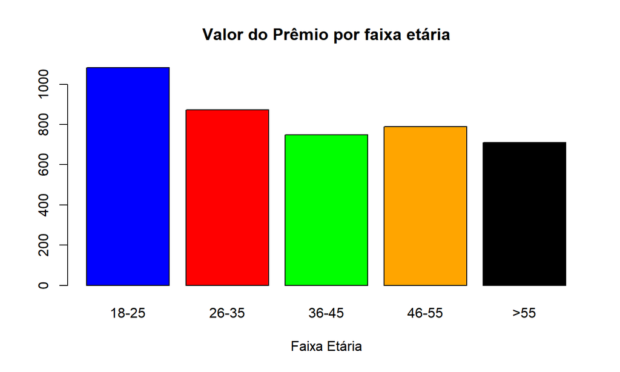

## Análise Descritiva

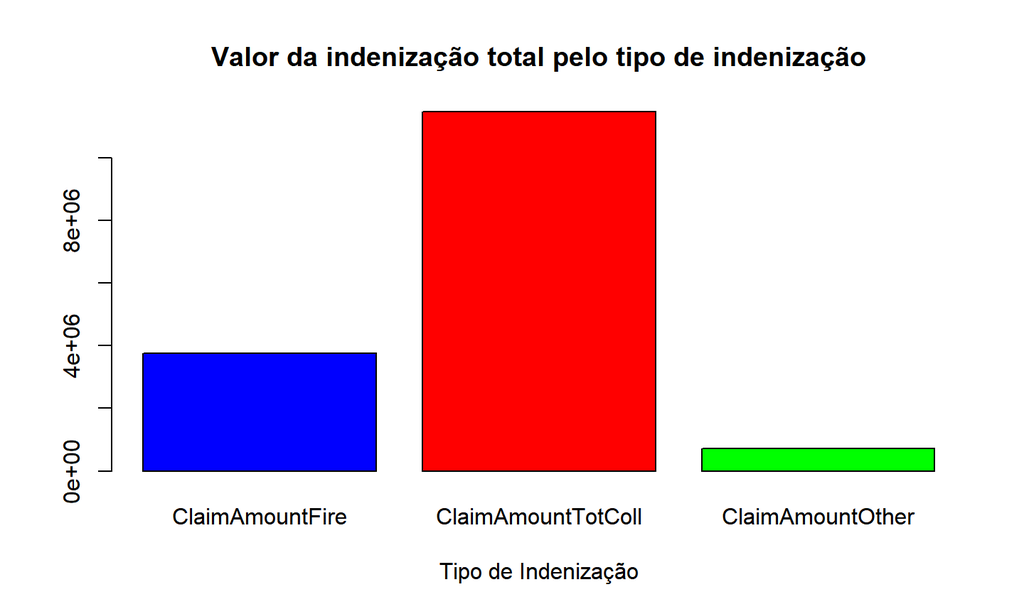

## Análise Descritiva

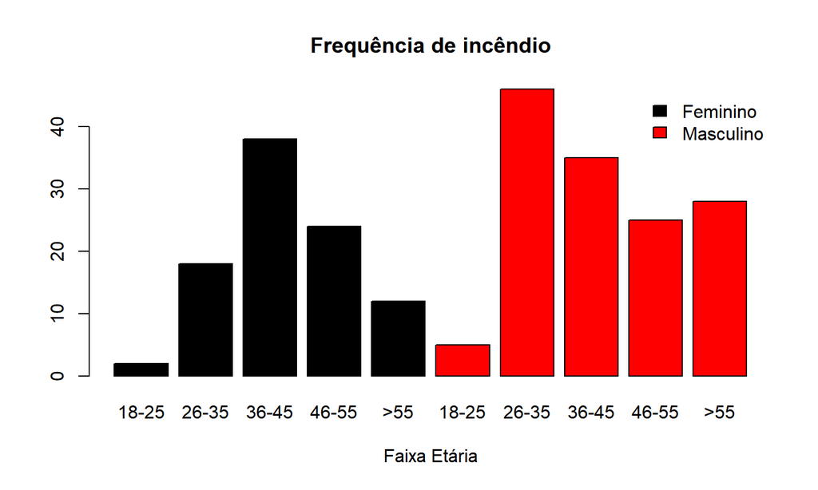

## Análise Descritiva

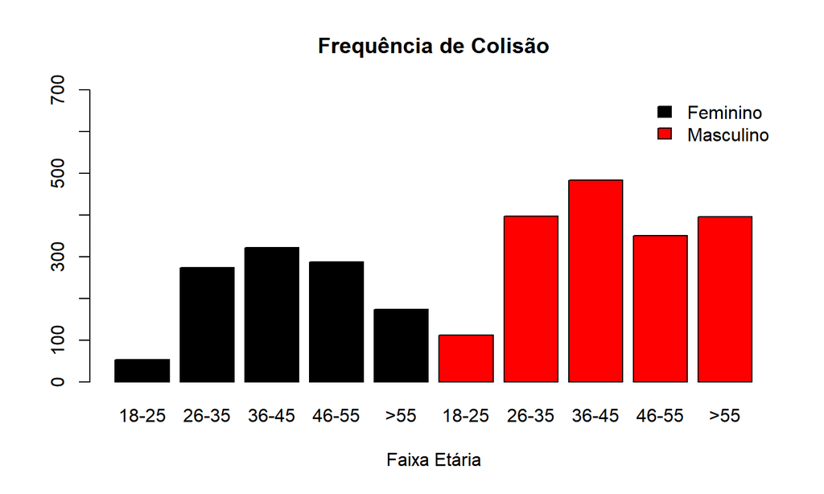

## Análise Descritiva

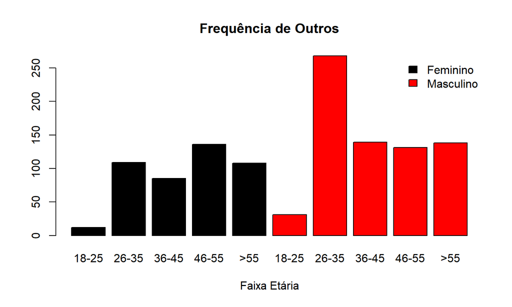

## Ajuste do Modelo

## Ajuste do Modelo

```
##
## Call:
## glm(formula = ClaimNbTotColl ~ Gender + DrivAge + offset(log(ExposTotal)),
##     family = poisson(link = "log"), data = brvehins1a)
##
## Deviance Residuals:
##       1        2        3        4        5        6        7        8
## -0.2617   0.3515  -0.5468   0.9783  -0.7603   0.1833  -0.2886   0.4537
##       9       10
## -0.8558   0.5174
##
## Coefficients:
##              Estimate Std. Error z value Pr(>|z|)
## (Intercept)  -2.65003    0.04943 -53.616  < 2e-16 ***
## GenderMale    0.08978    0.03856   2.329 0.019880 *
## DrivAge18-25  0.55574    0.08844   6.284 3.30e-10 ***
## DrivAge26-35  0.29169    0.05709   5.109 3.24e-07 ***
## DrivAge36-45  0.29153    0.05489   5.311 1.09e-07 ***
## DrivAge46-55  0.21819    0.05784   3.772 0.000162 ***
## ---
## Signif. codes:  0 '***' 0.001 '**' 0.01 '*' 0.05 '.' 0.1 ' ' 1
##
## (Dispersion parameter for poisson family taken to be 1)
##
##     Null deviance: 60.996  on 9  degrees of freedom
## Residual deviance:  3.349  on 4  degrees of freedom
## AIC: 88.629
##
## Number of Fisher Scoring iterations: 3
```

## Ajuste do Modelo

-Neste caso a Deviance residual é de 3.349, com 4 graus de liberdade, diferença < 1 .

-Para uma melhor confirmação do ajuste, comparamos o valor da Deviance com a Qui-Quadrado, sendo esta no valor de 9,488 para 4 graus de liberdade e 0,95 % de confiança, afirmamos que o nosso modelo está bem ajustado.

-Notamos também que todas as variáveis foram significativas.

## Ajuste do Modelo

-Interpretação dos parâmetros:

-β1: Para um acréscimo de uma unidade em sexo, a razão de chance aumenta em 9,39%.

-β22: Para um acréscimo de uma unidade em Faixa Etária entre 26 e 35 anos, temos um aumento de 33,87% na razão de chance.

-β23: Para um acréscimo de uma unidade em Faixa Etária entre 36 e 45 anos, temos um aumento de 33,85% na razão de chance.

-β24: Para um acréscimo de uma unidade em Faixa Etária entre 46 e 55 anos, temos um aumento de 24,38% na razão de chance.